# Data-based Statistical Decision Model_0809

Hyeonho Lee

2018년 8월 9일

통계적 모델링 vs 딥러닝 모델링

딥러닝은 왜 잘되는지 모르겠다. 다른 데이터를 넣었을 때도 잘되는지에 대한 확신을 할 수 없다.(물론 거의 다 잘되긴 한다.)

일반화를 할 수 없다.

분포를 알고 있을때, b0, b1을 알수있다.(모집단(데이터)에서 샘플링을 한다..?)

요새 나오는 데이터는 모집단 중 몇개 샘플을 선정하는 방식이 아니다.

데이터가 계속 들어오는 방식이다. (실시간, 스트리밍 데이터?)

### Why it’s reasonable to do statistical inference on a complete data set

1. 측정할 때 생기는 error - 실제값보다 높게 or 낮게 나오는.. systematic(설명을 할 수 있는 error)는 모델에 반영이 되어야 한다.
2. statistical error은 왜 생기는지 모르는 error/ but 에러의 분포는 알 수 있다. (sampling distribution)

가정 : systematic에러가 없다면, 에러의 분포는 알 수 있다. 에러가 정규분포의 분산을 부여했을 때 따를 수도 있다.?

3. Account for accidental values : aiming at the general, underlying trends
4. 데이터의 분포가 있다고 할 때, 과거로 돌아가서 다시 관측하여도 분포는 동일하다고 한다.?

### Statistical Models

x와 y가 관계가 있는데 어떤 관계가 있다. = 이것도 모형임.

### Example: Conceivable statistical models for the BEA data

1. X값이 정해져 있을 때, Y값이 정해져 있다. // X와 Y|X는 정규분포를 따를 때, 별로 안좋은 모형임
2. X는 어떠한 무한개의 정규분포를 따른다. // Y|X는 정규분포 정해진거.
3. Y|X의 분산은 임의의 분산
4. X는 어떤 무한개의 분산
5. x와 y의 관계는 선형이다. - 굉장히 General 해지고 있음.
6. 점점 relax해지는 과정
7. X나 Y나 독립은 아닐수도 있지만 uncorrelation

7 > 6 > 5 > 4 > 3 > 2 > 1

### Models, inference and model checking

1번 같은 모형은 쓰이지 않는다.

7번도 가정이 많이 들어간 경우.

가정이 많이 들어간 모형일 수록 설명해야 하는 부분이 적어진다.

적게 들어갈수록 어려워진다.

이 모형이 맞다고 가정했을 때, parameter와 prediction check

모형에 대한 check가 필요

model checking은 답이 없다.

이렇게 해야 맞는거다라는 사람의 의견이 전부 다르다.(Art적인 부분, 이정도면 내가 이렇게 볼 수 있을 것 같다. <경험의 차이>)

### Simple Linear Regression

- 7번 모형을 적용 시킨다

x의 분포는 가정을 하지 않는다, (deterministic : 랜덤이 아니다.)

x와 y는 선형관계이다. noise는 값으로 들어간다.

분산은 똑같은 분산으로 나온다. 등분산성??, noise값은 x와 관계가 없다. 오늘 noise와 내일 noise는 서로 관게가 없다. 잔차의 등분산성, 독립성인가..??

noise값의 평균이 0이라는 가정은 별로 중요하지않다.

linear regression은 general한 모형이다.

b0 and b1 의 optimal linear predictor?

### Estimation

b1 = cov(x, y) / var(x)

data point가 n개가 있을 때, b1을 찾을 수 있다.

s^2 = 1/n sigma(xi - bar(x))^2

cov(x, y) = 1/n(xi-bar(x))(yi-bar(y))

### Inference: What can we say more about the model?

b1이 얼마나 좋은가?

샘플에서 계산한 b1 hat이 b1과 같은가? - 다르다. 물론 같을 수도 있다.

b1 hat은 b1과 언제 비슷할까? - n이 충분히 클때 성립한다. b1 = Cov(x, y)/var(x), b1 hat = Cxy/Sx^2

대수의 법칙의 의해서( xi들의 평균을 구하면 expected x로 간다. i가 충분히 크면)

observation을 많이 하면 할 수록 정확도 올라간다.

what is the expected magnitude “b1 hat - b1”?

꼬리의 noise가 두텁다.

### The optimal linear predictor

m(x)=E[Y]+Cov[X,Y]/VarX

equals the model formula β0+β1x , if the model is true.

### Estimation

1. From the optimal linear predictor of Y
2. From the objective function(“MSE”)

linear regression은 sample variance가 0인경우 할 수 없는데, 이건 말이 안된다..

### How good these estimates are?

1. bias가 존재하는지 안하는지를 확인, 평균적으로 b1에 있으면 unbias라고 이야기한다.
2. variance의 크기를 봐야한다. variance자체는 이야기할게 없지만 작으면 더 좋다.
3. b1의 sampling distribution of b1 hat, but it is not possible(가정을 충분히 하지 않았기 때문에)

### Constant plus noise representation

Note that the “noise” term is a weighted sum of uncorrelated noises.

Also note that we have used a model assumption here (which one?).

### 일부로 bias를 주어서 mse를 낮추는 방법…lasso ridge

MSE(b1 hat) = var(b1 hat) + bias(b1 hat)

### Predictions

머신러닝의 경우 예측값에 대해 이야기하는것이 또 중요.

예측도 여러가지 종류가 있다.

Var(m^(x))=σ2n(1+(x−x¯)2s2X) 이 식이 의미하는 바 :

데이터의 중심 x bar 에서 멀어질수록 분산이 증가하므로 예측력이 떨어진다.

### Estimating sigma^2

. s2=nn−2σ^2 이게 나올 수도 있다.

### Residuals는 모델 checking 할때 많이 쓰인다.

(mhat(xi))Residuals vs y hat

ei != Ei(입실론i)

### Limitations of Least Squares

어떤의미에서 가장 좋은 estimate인가?

옛날엔 중요햇는데 요즘엔 안중요 가정이 틀렸을때의 (틀린 가정에서의 모델의 estimate가 좋아서 뭐하는가)

distribution가정을 더해서 더 볼것이다.

### R demonstration

```r
sim.linmod <- function(n, beta.0, beta.1, width, df) {
    # draw n points from a uniform distribution centered on 0
    x <- runif(n, min=-width/2, max=width/2)
    # draw n points from a t distribution with the given number of degrees
    # of freedom
    epsilon <- rt(n, df=df)
    # make y from a linear model
    y <- beta.0 + beta.1*x + epsilon
    # return the data frame
    return(data.frame(x=x, y=y))
}
```

```r
 # Make a very small simulated data set from our running examing
toy.data <- sim.linmod(n=10, beta.0=5, beta.1=-2, width=4, df=3)
# Fit the simple linear regression model to it by least squares
lm(y~x, data=toy.data)
```

```
##
## Call:
## lm(formula = y ~ x, data = toy.data)
##
## Coefficients:
## (Intercept)            x
##       4.333       -3.285
```

```r
names(lm(y~x, data=toy.data))
```

```
##  [1] "coefficients"  "residuals"     "effects"       "rank"
##  [5] "fitted.values" "assign"        "qr"            "df.residual"
##  [9] "xlevels"       "call"          "terms"         "model"
```

```r
toy.lm <- lm(y~x, data=toy.data)
```

```r
coefficients(toy.lm)
```

```
## (Intercept)           x
##    4.333211   -3.285076
```

```r
fitted(toy.lm)
```

```
##           1           2           3           4           5           6
##  7.30912098  8.14111436  4.77069874  0.11833498  3.70181990  0.05499535
##           7           8           9          10
## -1.83208146 -0.92337223  4.50289520  3.76148525
```

```r
residuals(toy.lm)
```

```
##          1          2          3          4          5          6
## -1.9121874  2.2957107 -0.6887252  2.2070780 -1.2588992 -0.3830679
##          7          8          9         10
##  3.7271547 -5.1627522  0.8518248  0.3238636
```

```r
predict(toy.lm, newdata=data.frame(x=1:5))
```

```
##          1          2          3          4          5
##   1.048135  -2.236941  -5.522017  -8.807093 -12.092168
```

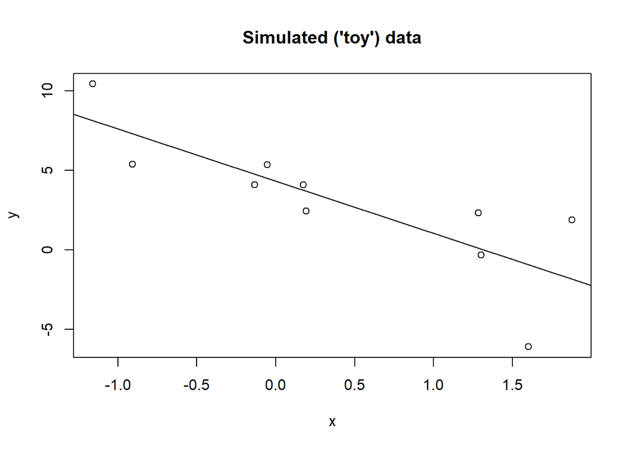

```r
plot(y~x, data=toy.data, xlab="x",ylab="y", main="Simulated ('toy') data")
abline(toy.lm)
```

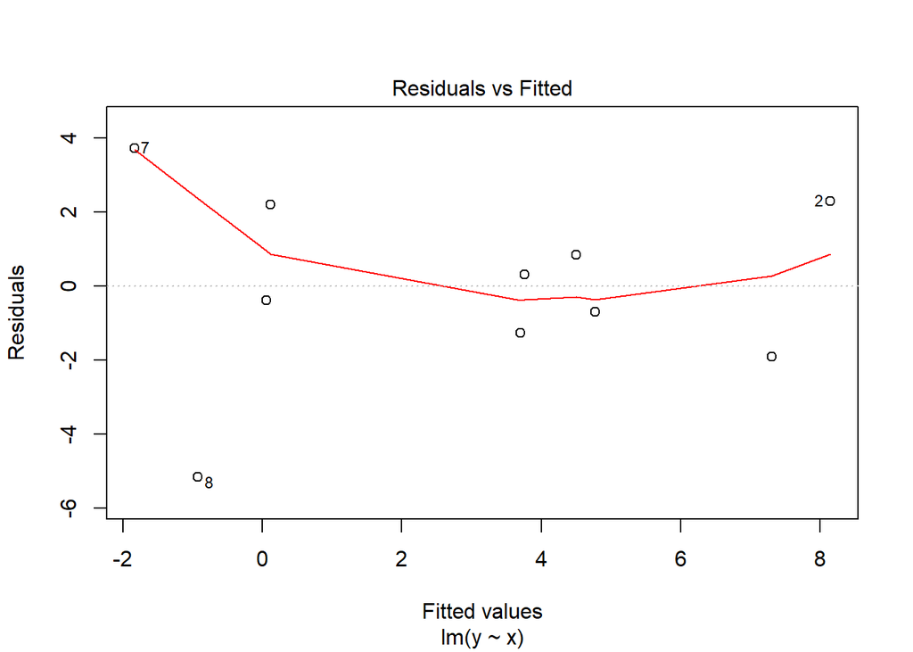

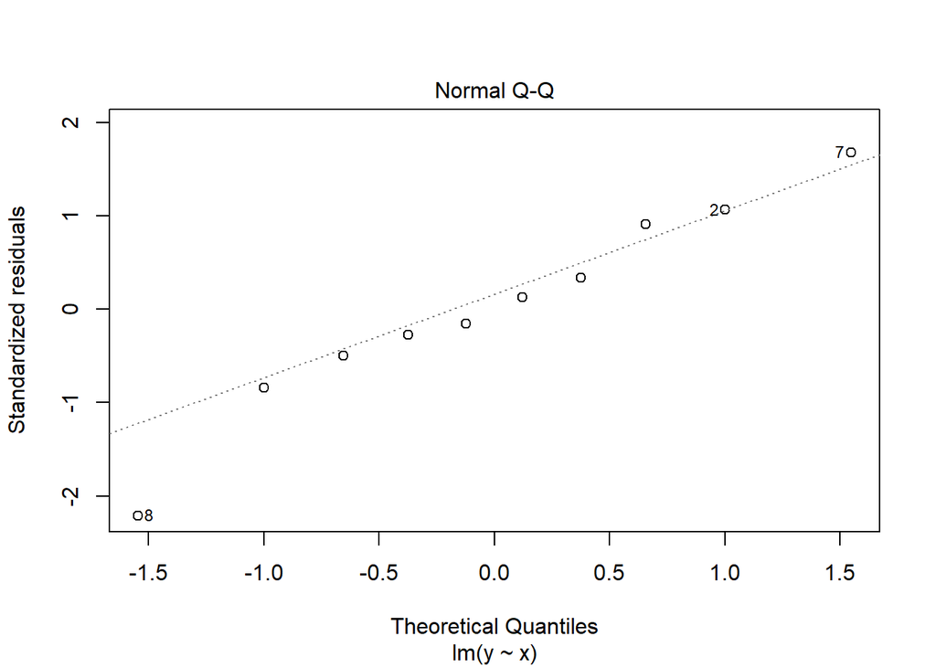

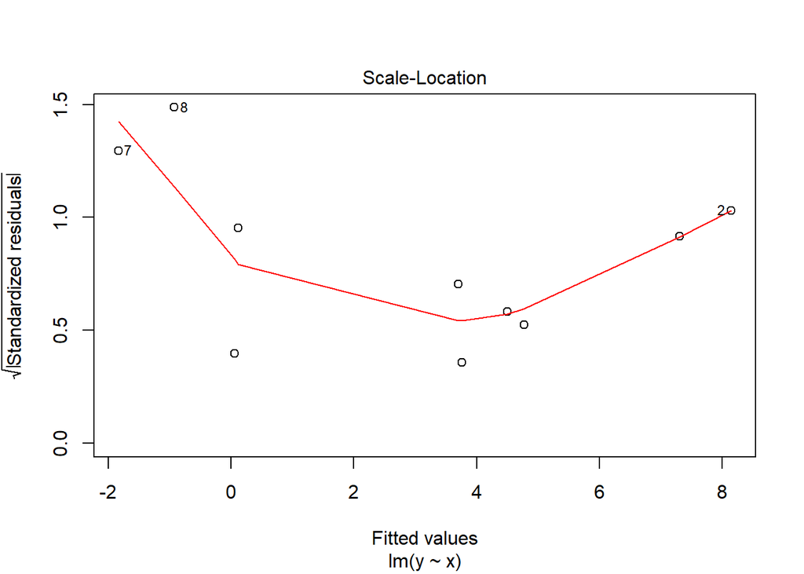

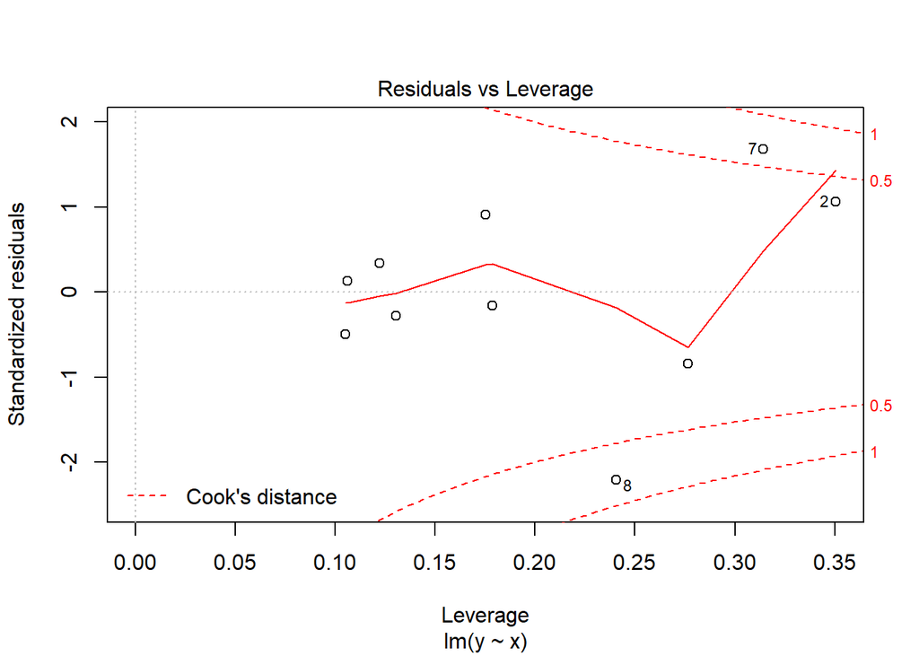

```r
plot(toy.lm)
```

### The Gaussian-Noise Simple Linear Regression Model

지금까지는 정규분포가정을 하지 않고 했다.

정규분포를 가정하고 이야기하게 되면 더 많은 이야기를 할 수 있다.

### why gaussian noise?

1. central limit theorm
2. mathematical convenience

### The gaussian-noise simple linear regression model

estimation by maximzing the likelihood

Advantages of the Gaussian model

noise에 대한 normal distribution

(데이터)분포를 알고 있을 때, mle를 가장 크게 만드는 parameter을 찾아줄수 있다면, 최소제곱법으로 찾은

더 좋은 estimeter라고 할 수 있다.

모델에 대한 작업 —- mse or sse를 가장 작게하는

분포를 안다면 mle가 가장 좋다………………———- mle == modeling 이렇게 만드는게 가장 좋은거라는거네 그럼

### Model checking or so-called diagnostics